# 01_FeatureSelection_Luise

Sera Choi

14/05/2021

## Feature selection of Luise’s dataset

- After quality control, normalisation and integration steps were skipped because the dataset has been normalised and stringent experimental design has minimised batch effect
- Feature selection aims to select genes that carry most interesting biological information, while eliminating those that introduce noise

```r
# Load library
library(Seurat)
library(ggplot2)
library(dplyr)
library(here)
library(scran)

# Load data
ecpc <- readRDS(here("data/processed/ecpc00.RDS"))
```

## Feature selection

Feature selection aims to select genes that carry most interesting biological information while eliminating those that introduce noise. Seurat feature selection function learns mean-variance relationship from the data and computes estimated variance of each gene given the mean. Using this estimated variance, variance-stabilising transformation is performed to standardise the value of a gene. Then, for each gene, variance of standardised value across all cells is calculated and ranked. Top 2000 genes with highest variance given mean are subsetted and stored in VariableFeatures(ecpc).

Top 10 HVGs are printed, which are also labelled in the plot below.

```r
# VariableFeatures(ecpc) contains top 2000 highly variable genes
ecpc <- FindVariableFeatures(ecpc, selection.method = "vst", nfeatures=2000)

# Identify top 10 HVGs
top10 <- head(VariableFeatures(ecpc), 10)
top10
```

```
##  [1] "ADAMTS9"    "HBA2"       "HBB"        "NRG3"       "AC105402.3"
##  [6] "HBA1"       "CTNNA2"     "ANGPT2"     "SKAP1"      "PCDH9"
```

## Feature Selection plot

Here, I plotted mean-variance relationship of genes, with top 2000 HVGs highlighted in red. x-axis annotation: 0.01, 1, 100

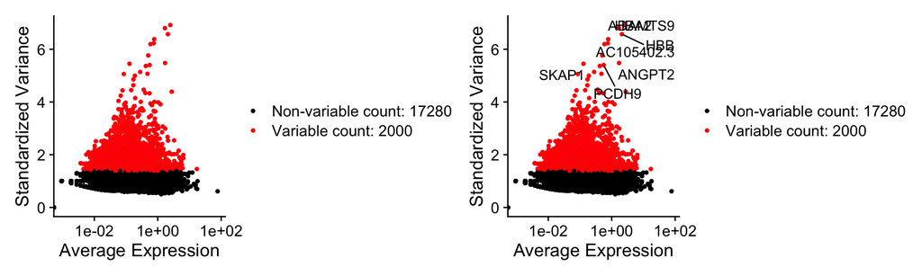

```r
# Plot variable features with and without labels
plot1 <- VariableFeaturePlot(ecpc)
plot2 <- LabelPoints(plot = plot1, points = top10, repel = TRUE)
plot1 + plot2
```

```r
# Update Seurat object
saveRDS(ecpc, "/Users/serachoi/Documents/Edinburgh/MScProject/Project/data/processed/ecpc01.RDS")
```